# Understanding video game sale trends

#### By Rajat Vemuri & Dimetros Seleshi

# Introduction

Video Games have been around for years. It started in 1958 when a physicist created pong. Video games have progressed mightily ever since, and there are many new genres out, and a wide range of player base. People play games such as action, adventure, shooters, platformers and much much more. And over time we can see how the general trends of video game genres has changed, and maybe how critic, and user scores affect these sales over time. In our tutorial we will show how over time the trends of video game genres have changed, how many people play different kinds of games and how user/critic ratings have changed over time.

If you want an overview of how games have sold and their genres, you should visit this [website](https://vgsales.fandom.com/wiki/Video_game_industry) to learn more.

### Table of contents:

# Preliminary

We complete the project using these data analytics libraries. Scipy, sklearn, pandas, numpy, matplotlib and seaborn.

```python
from scipy import stats
from sklearn import linear_model
from sklearn import model_selection
import pandas as pd
import numpy as np
import matplotlib.pyplot as plt
import seaborn as sns
import statsmodels.formula.api as sm
%config InlineBackend.figure_format = 'retina'
%matplotlib inline
```

```python
data = pd.read_csv('Video_Game.csv')
data['User_Score'] = data['User_Score'] * 10
data = data[data.Year_of_Release.notnull()]
data = data.loc[data.Year_of_Release < 2017]
data.Year_of_Release = data['Year_of_Release'].astype(int)
data = data.dropna()
data
```

|  | Name | Platform | Year_of_Release | Genre | Publisher | NA_Sales | EU_Sales | JP_Sales | Other_Sales | Global_Sales | Critic_Score | Critic_Count | User_Score | User_Count | Rating |
| --- | --- | --- | --- | --- | --- | --- | --- | --- | --- | --- | --- | --- | --- | --- | --- |
| 0 | Wii Sports | Wii | 2006 | Sports | Nintendo | 41.36 | 28.96 | 3.77 | 8.45 | 82.54 | 76.0 | 51.0 | 80.0 | 324.0 | E |
| 2 | Mario Kart Wii | Wii | 2008 | Racing | Nintendo | 15.68 | 12.80 | 3.79 | 3.29 | 35.57 | 82.0 | 73.0 | 83.0 | 712.0 | E |
| 3 | Wii Sports Resort | Wii | 2009 | Sports | Nintendo | 15.61 | 10.95 | 3.28 | 2.95 | 32.78 | 80.0 | 73.0 | 80.0 | 193.0 | E |
| 6 | New Super Mario Bros. | DS | 2006 | Platform | Nintendo | 11.28 | 9.15 | 6.50 | 2.88 | 29.81 | 89.0 | 65.0 | 85.0 | 433.0 | E |
| 7 | Wii Play | Wii | 2006 | Misc | Nintendo | 13.96 | 9.18 | 2.93 | 2.84 | 28.92 | 58.0 | 41.0 | 66.0 | 129.0 | E |
| ... | ... | ... | ... | ... | ... | ... | ... | ... | ... | ... | ... | ... | ... | ... | ... |
| 17394 | Tom Clancys Splinter Cell | PC | 2003 | Action | Ubisoft | 0.00 | 0.00 | 0.00 | 0.00 | 0.01 | 91.0 | 20.0 | 85.0 | 291.0 | T |
| 17401 | Blacksite: Area 51 | PC | 2007 | Shooter | Midway Games | 0.00 | 0.00 | 0.00 | 0.00 | 0.01 | 60.0 | 20.0 | 49.0 | 42.0 | T |
| 17402 | Virtua Tennis 2009 | PC | 2009 | Sports | Sega | 0.00 | 0.00 | 0.00 | 0.00 | 0.01 | 68.0 | 8.0 | 65.0 | 19.0 | E |
| 17404 | CivCity: Rome | PC | 2006 | Strategy | Take-Two Interactive | 0.00 | 0.00 | 0.00 | 0.00 | 0.01 | 67.0 | 46.0 | 69.0 | 32.0 | E10+ |
| 17407 | Super Meat Boy | PS4 | 2016 | Platform | Team Meat | 0.00 | 0.00 | 0.00 | 0.00 | 0.01 | 85.0 | 7.0 | 70.0 | 114.0 | T |

7112 rows × 15 columns

## The Data

The dataset we are using is a large aggregate of notable video games so far. We are extracting the data off a csv, it contains the following data:

name: Name of video game

Platform: the console the video game is played on

Year_of_Release: What year the video game released

Genre: type of video game

Publisher: who made the video game

NA/EU/JP/Other/World_Sales: how many (in millions) did the video game sell in that region

Critic_Score: The average score given to the video game by critics

Critic_Count: The amount of critics that reviewed the video game

User_Score: The average score given to the video game by consumers

User_Count: The amount of user reviews

Rating: The ESRB age rating for the video game

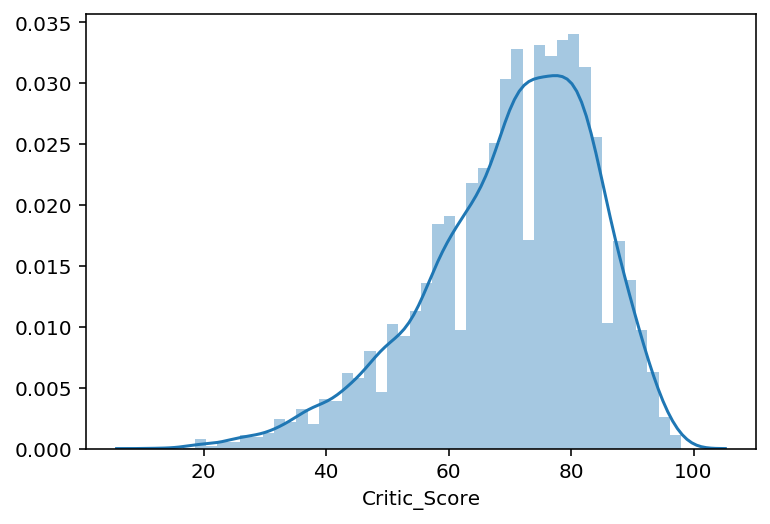

```python
sns.distplot(a=data['Critic_Score'])
```

### Critic Scores

This graph is plotted using seaborn, and shows the critic score, and what the most and least common scores given out to video games are. As we can tell the mode is somewhere around a 78-80%. This is suprising because when you think of critics in most other professions we think they are very hard to please because they are trying to find the flaws in everything. This isnt the case in the world of gaming because most review sites actually work with the games being reviewed. This has been a known problem for a while and this data reflects that fact.

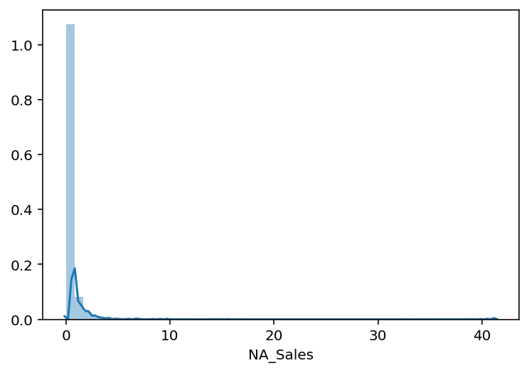

```python
sns.distplot(a=data['NA_Sales'])
```

## North American Sales

This chart is strange, what it is showing that there are only a few games that sell a cut above the rest. Everything else is on roughly the same level. maybe 5% of games get top seller status in North America. If you really think about it there are so many games that get released in a year but only a few end up selling very well. This kind of gulf between high selling games and low selling ones isnt exclusive to the gameing industry but it is a problem that happens here non the less.

```python
data = data.loc[data.Year_of_Release >= 1990]
yearly_avg_sales = pd.pivot_table(data,index=['Year_of_Release'],
                     columns=['Genre'],values=['Global_Sales'])
yearly_avg_sales.columns = yearly_avg_sales.columns.get_level_values(1)
yearly_avg_sales = yearly_avg_sales.dropna()
yearly_avg_sales = yearly_avg_sales.drop(yearly_avg_sales.index[0])
yearly_avg_sales = yearly_avg_sales.drop(yearly_avg_sales.index[0])
yearly_avg_sales = yearly_avg_sales.drop(yearly_avg_sales.index[0])
yearly_avg_sales
```

| Genre Year_of_Release | Action | Adventure | Fighting | Misc | Platform | Puzzle | Racing | Role-Playing | Shooter | Simulation | Sports | Strategy |
| --- | --- | --- | --- | --- | --- | --- | --- | --- | --- | --- | --- | --- |
| 2003 | 0.498039 | 0.142222 | 0.610690 | 0.557500 | 0.531731 | 0.070000 | 0.458906 | 0.747187 | 0.408095 | 0.634333 | 0.620471 | 0.223704 |
| 2004 | 0.738764 | 0.251304 | 0.477879 | 0.448846 | 0.639487 | 0.474286 | 1.012439 | 0.807234 | 0.649859 | 0.548235 | 0.787671 | 0.205652 |
| 2005 | 0.488369 | 0.223333 | 0.523929 | 1.424074 | 0.385500 | 1.277857 | 1.052857 | 0.410200 | 0.424607 | 0.880000 | 0.532875 | 0.202941 |
| 2006 | 0.482190 | 0.253636 | 0.514194 | 2.691176 | 1.427576 | 0.765000 | 0.542545 | 0.508657 | 0.717273 | 0.533636 | 1.435287 | 0.107333 |
| 2007 | 0.592197 | 1.396000 | 0.653043 | 1.541064 | 1.006667 | 0.578000 | 0.622308 | 0.622075 | 0.899868 | 0.672683 | 0.851000 | 0.131538 |
| 2008 | 0.884545 | 0.170667 | 1.090690 | 0.925577 | 0.767353 | 0.512857 | 1.463023 | 0.733553 | 0.853281 | 0.738571 | 0.711111 | 0.308182 |
| 2009 | 0.656483 | 0.204444 | 0.878438 | 0.854694 | 2.133529 | 0.610625 | 0.651471 | 0.651228 | 0.884444 | 0.738500 | 1.414789 | 0.286071 |
| 2010 | 0.739565 | 0.515000 | 0.552273 | 1.701842 | 1.822143 | 0.587778 | 0.893667 | 0.767818 | 1.339636 | 0.556000 | 0.993065 | 0.531053 |
| 2011 | 0.738116 | 0.531111 | 0.565833 | 0.851818 | 1.116087 | 0.237500 | 0.947097 | 1.116486 | 1.278816 | 0.324118 | 0.674146 | 0.270417 |
| 2012 | 0.790560 | 0.180000 | 0.387727 | 1.325714 | 2.205000 | 0.445000 | 0.376500 | 0.903529 | 1.727317 | 1.079167 | 0.798000 | 0.487500 |
| 2013 | 1.242353 | 0.463333 | 0.485455 | 0.753000 | 0.720417 | 0.316667 | 0.868571 | 0.390968 | 1.292979 | 0.967500 | 1.367037 | 0.602500 |
| 2014 | 0.801975 | 0.107143 | 0.180909 | 0.331667 | 1.043750 | 0.635000 | 0.782500 | 0.370392 | 1.515000 | 0.960000 | 0.887097 | 0.156667 |
| 2015 | 0.601067 | 0.404444 | 0.655000 | 0.506000 | 0.650000 | 0.040000 | 0.483000 | 0.941724 | 1.565556 | 0.634286 | 1.218000 | 0.158889 |
| 2016 | 0.324557 | 0.108824 | 0.385000 | 0.173750 | 0.133636 | 0.020000 | 0.182000 | 0.367692 | 1.272500 | 0.306667 | 1.050000 | 0.210000 |

## Mean Sales per Genre by Year

This chart is important. It gives us a yearly listing of average global sales (in millions) of video games by genre. We can explore trends using this chart and understand how over time how the most played genres change.

We made this chart by dropping columns we didnt need, to calculate this chart we took years, genre and global_sales and aggregrated them to list the mean sales per year by genre.

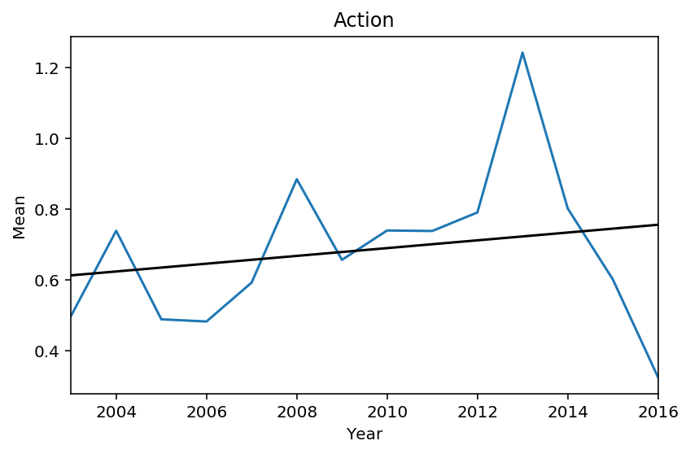

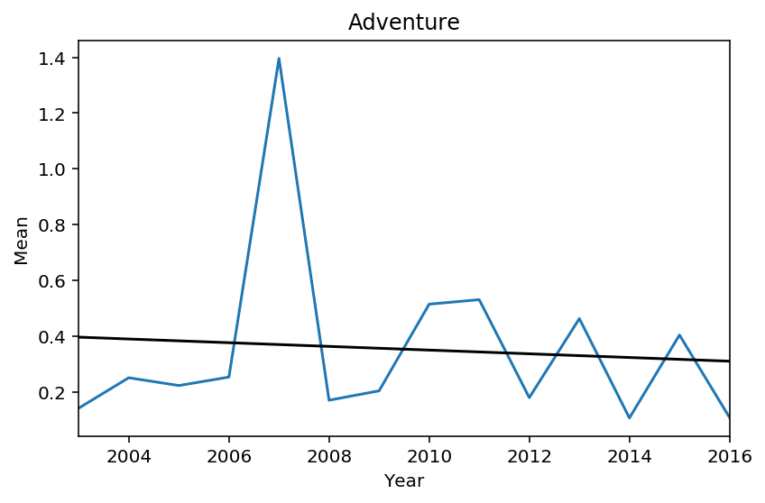

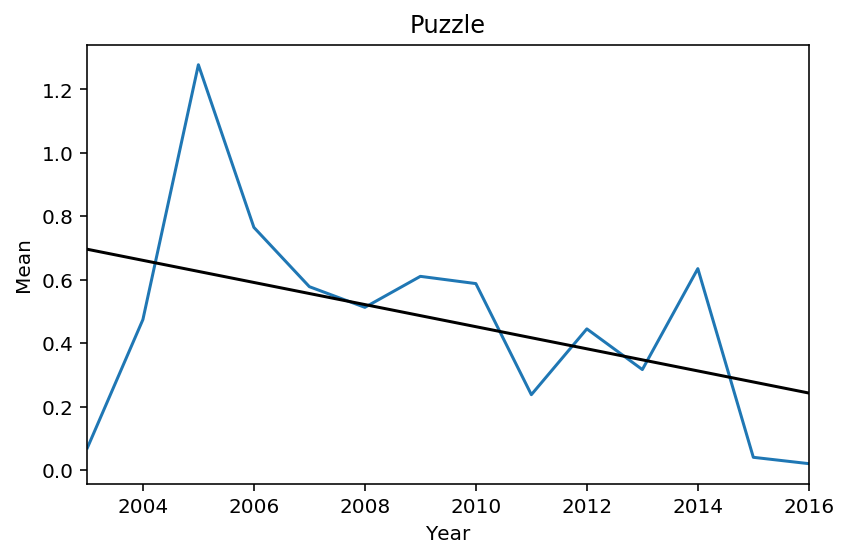

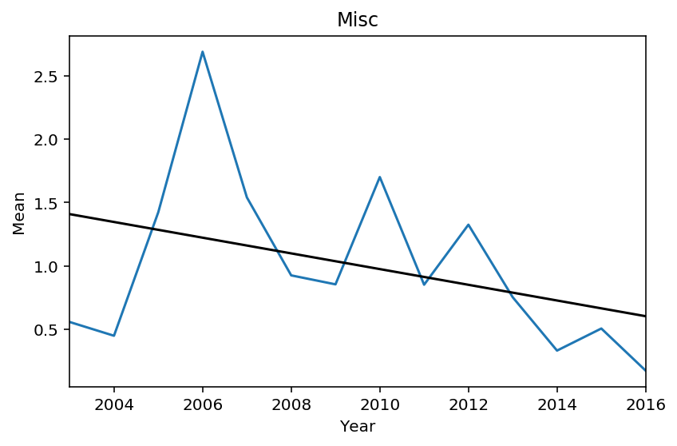

```python
    genre = yearly_avg_sales['Action']
    Regr_Coeff = []
    Regr_MSE = []
    fig, axes = plt.subplots()

    xval = np.transpose(np.matrix(yearly_avg_sales.index))

    count = 0

    yvals = genre.to_frame()

    # Linear regression
    regr = linear_model.LinearRegression()
    regr.fit(xval,yvals)

    # Mean Squared Error
    MSE = np.mean((regr.predict(xval)-yvals)**2)

    Regr_Coeff.append(regr.coef_[0][0])
    Regr_MSE.append(MSE[0])

    genre.plot(ax=axes)
    axes.plot(xval,regr.predict(xval), color='black')

    y_lims = axes.get_ylim()



    y_loc = 0.85*(y_lims[1]-y_lims[0])+y_lims[0]


    axes.set_title('Action')
    axes.set_xlabel('Year')
    axes.set_ylabel('Mean')
    count+=1
    fig.tight_layout()

    genre = yearly_avg_sales['Adventure']
    Regr_Coeff = []
    Regr_MSE = []
    fig, axes = plt.subplots()

    xval = np.transpose(np.matrix(yearly_avg_sales.index))

    count = 0



    yvals = genre.to_frame()

    # Linear regression
    regr = linear_model.LinearRegression()
    regr.fit(xval,yvals)

    # Mean Squared Error
    MSE = np.mean((regr.predict(xval)-yvals)**2)

    Regr_Coeff.append(regr.coef_[0][0])
    Regr_MSE.append(MSE[0])

    genre.plot(ax=axes)
    axes.plot(xval,regr.predict(xval), color='black')

    y_lims = axes.get_ylim()



    y_loc = 0.85*(y_lims[1]-y_lims[0])+y_lims[0]


    axes.set_title('Adventure')
    axes.set_xlabel('Year')
    axes.set_ylabel('Mean')
    count+=1
    fig.tight_layout()


    genre = yearly_avg_sales['Puzzle']
    Regr_Coeff = []
    Regr_MSE = []
    fig, axes = plt.subplots()

    xval = np.transpose(np.matrix(yearly_avg_sales.index))

    count = 0

    yvals = genre.to_frame()

    regr = linear_model.LinearRegression()
    regr.fit(xval,yvals)


    MSE = np.mean((regr.predict(xval)-yvals)**2)

    Regr_Coeff.append(regr.coef_[0][0])
    Regr_MSE.append(MSE[0])

    genre.plot(ax=axes)
    axes.plot(xval,regr.predict(xval), color='black')

    y_lims = axes.get_ylim()



    y_loc = 0.85*(y_lims[1]-y_lims[0])+y_lims[0]


    axes.set_title('Puzzle')
    axes.set_xlabel('Year')
    axes.set_ylabel('Mean')
    count+=1
    fig.tight_layout()

    genre = yearly_avg_sales['Misc']
    Regr_Coeff = []
    Regr_MSE = []
    fig, axes = plt.subplots()

    xval = np.transpose(np.matrix(yearly_avg_sales.index))

    count = 0



    yvals = genre.to_frame()


    regr = linear_model.LinearRegression()
    regr.fit(xval,yvals)

    MSE = np.mean((regr.predict(xval)-yvals)**2)

    Regr_Coeff.append(regr.coef_[0][0])
    Regr_MSE.append(MSE[0])

    genre.plot(ax=axes)
    axes.plot(xval,regr.predict(xval), color='black')

    y_lims = axes.get_ylim()



    y_loc = 0.85*(y_lims[1]-y_lims[0])+y_lims[0]


    axes.set_title('Misc')
    axes.set_xlabel('Year')
    axes.set_ylabel('Mean')
    count+=1
    fig.tight_layout()
```

## Regression Analysis

[figure not shown]

```python
    genre = yearly_avg_sales['Shooter']
    Regr_Coeff = []
    Regr_MSE = []
    fig, axes = plt.subplots()

    xvals = np.transpose(np.matrix(yearly_avg_sales.index))
    count = 0
    yvals = genre.to_frame()
    regr = linear_model.LinearRegression()

    regr.fit(xvals,yvals)
    MSE = np.mean((regr.predict(xvals)-yvals)**2)
    Regr_Coeff.append(regr.coef_[0][0])
    Regr_MSE.append(MSE[0])
    genre.plot(ax=axes)
    axes.plot(xvals,regr.predict(xvals), color='black')

    y_lims = axes.get_ylim()
    y_loc = 0.85*(y_lims[1]-y_lims[0])+y_lims[0]
    axes.set_title('Shooter')
    axes.set_xlabel('Year')
    axes.set_ylabel('Mean')
    count+=1
    fig.tight_layout()
```

## Shooter Games

We would like to point out shooter games, using regressional analysis we can see that this genre experienced the largest growth out of any other genre over the years. This was plotted using the same method as before. The fact that this genre isnt effect by the slump in sales growth actually may give us insight into what may be causing a overall decline in game sales. These game sales are for console and PC gaming but no mobile gaming. We also know that shooting games dont translate well to mobile games so the reason why games are on the downhill in terms of sales may have to do with the fact handheld games are taking over.

```python
yearly_avg_score = pd.pivot_table(data,index=['Year_of_Release'],
                     columns=['Genre'],values=['Critic_Score'])
yearly_avg_score = yearly_avg_score.dropna()
yearly_avg_score.columns = yearly_avg_score.columns.get_level_values(1)
yearly_avg_score
```

| Genre Year_of_Release | Action | Adventure | Fighting | Misc | Platform | Puzzle | Racing | Role-Playing | Shooter | Simulation | Sports | Strategy |
| --- | --- | --- | --- | --- | --- | --- | --- | --- | --- | --- | --- | --- |
| 2000 | 64.266667 | 67.333333 | 61.888889 | 75.000000 | 73.000000 | 72.000000 | 71.928571 | 76.411765 | 68.900000 | 76.333333 | 83.384615 | 76.166667 |
| 2001 | 67.794118 | 72.250000 | 77.181818 | 66.636364 | 72.038462 | 83.333333 | 69.479167 | 73.636364 | 71.964286 | 77.611111 | 76.820000 | 78.250000 |
| 2002 | 69.543210 | 68.500000 | 67.794118 | 55.500000 | 67.090909 | 62.333333 | 68.833333 | 74.382353 | 71.590164 | 76.571429 | 76.166667 | 73.000000 |
| 2003 | 67.000000 | 67.444444 | 69.965517 | 66.700000 | 68.461538 | 79.000000 | 67.812500 | 75.718750 | 70.333333 | 78.700000 | 79.611765 | 74.555556 |
| 2004 | 67.426966 | 64.043478 | 68.212121 | 65.076923 | 71.794872 | 75.000000 | 70.146341 | 72.808511 | 70.281690 | 67.882353 | 77.698630 | 74.043478 |
| 2005 | 69.602837 | 63.380952 | 65.321429 | 67.037037 | 67.575000 | 67.500000 | 70.020408 | 70.300000 | 70.651685 | 73.240000 | 76.000000 | 71.529412 |
| 2006 | 64.742857 | 61.863636 | 71.096774 | 71.117647 | 65.030303 | 66.200000 | 68.163636 | 72.238806 | 68.618182 | 66.848485 | 70.425287 | 69.333333 |
| 2007 | 60.886364 | 72.500000 | 67.565217 | 63.319149 | 62.740741 | 69.880000 | 66.442308 | 68.792453 | 72.421053 | 69.048780 | 72.244444 | 69.769231 |
| 2008 | 66.356643 | 58.366667 | 69.965517 | 64.865385 | 65.735294 | 71.857143 | 66.488372 | 72.065789 | 68.546875 | 66.214286 | 67.345679 | 71.954545 |
| 2009 | 65.965517 | 58.703704 | 72.625000 | 72.938776 | 70.705882 | 73.687500 | 71.470588 | 71.684211 | 67.361111 | 68.850000 | 73.154930 | 71.678571 |
| 2010 | 66.582609 | 66.500000 | 67.954545 | 66.868421 | 74.357143 | 76.111111 | 71.333333 | 71.236364 | 68.872727 | 69.000000 | 70.951613 | 75.842105 |
| 2011 | 66.528986 | 68.444444 | 71.194444 | 67.939394 | 75.826087 | 64.750000 | 69.258065 | 76.432432 | 71.684211 | 59.470588 | 71.000000 | 68.583333 |
| 2012 | 71.368000 | 73.375000 | 71.954545 | 71.357143 | 79.625000 | 75.000000 | 73.800000 | 71.470588 | 74.073171 | 69.833333 | 77.066667 | 86.500000 |
| 2013 | 73.788235 | 71.333333 | 69.727273 | 72.200000 | 71.041667 | 73.333333 | 69.642857 | 69.870968 | 68.063830 | 52.875000 | 77.407407 | 67.125000 |
| 2014 | 69.641975 | 65.285714 | 67.363636 | 74.833333 | 79.000000 | 74.500000 | 70.300000 | 70.941176 | 75.156250 | 73.000000 | 69.935484 | 73.000000 |
| 2015 | 72.053333 | 78.444444 | 70.300000 | 75.266667 | 84.222222 | 76.000000 | 71.200000 | 77.586207 | 76.611111 | 74.714286 | 65.920000 | 73.222222 |
| 2016 | 69.898734 | 74.000000 | 74.750000 | 71.375000 | 69.636364 | 73.000000 | 74.400000 | 74.692308 | 76.361111 | 65.333333 | 78.560000 | 87.400000 |

## Mean Critic Scores per Genre by Year

This is another chart to help us understand what causes reasons for games of different genres to sell differently over time. Here we are looking at how critics rate games of different genres over time to see if there is any correlation.

We create this chart by using the Critic_Score field of the original graph, and find the mean of all games of that genre per year.

```python
score_list = []
for genre in yearly_avg_score.columns:
    temp_list = yearly_avg_score[genre].values
    sum = 0
    for i in temp_list:
        sum += i
    score_list.append(int(sum / 17))
score_graph = pd.DataFrame({'Genre':yearly_avg_score.columns, 'Critic Score':score_list})
score_graph
```

|  | Genre | Critic Score |
| --- | --- | --- |
| 0 | Action | 67 |
| 1 | Adventure | 67 |
| 2 | Fighting | 69 |
| 3 | Misc | 68 |
| 4 | Platform | 71 |
| 5 | Puzzle | 72 |
| 6 | Racing | 70 |
| 7 | Role-Playing | 72 |
| 8 | Shooter | 71 |
| 9 | Simulation | 69 |
| 10 | Sports | 74 |
| 11 | Strategy | 74 |

### Critic averages over all time per genre

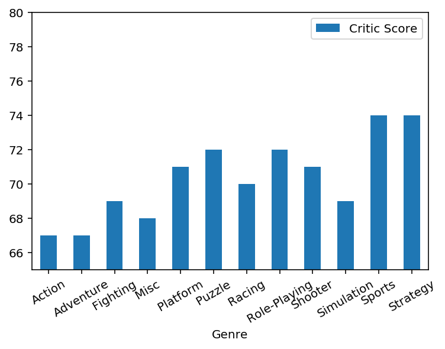

```python
ax = score_graph.plot.bar(x='Genre', y='Critic Score', rot=30, ylim=(65,80))
```

#### This is a bar graph represntation of Genre vs. Critic Scores over all time

```python
Mean_User = pd.pivot_table(data,index=['Year_of_Release'],
                     columns=['Genre'],values=['User_Score'])
Mean_User.columns = Mean_User.columns.get_level_values(1)
Mean_User = Mean_User.dropna()
Mean_User
```

| Genre Year_of_Release | Action | Adventure | Fighting | Misc | Platform | Puzzle | Racing | Role-Playing | Shooter | Simulation | Sports | Strategy |
| --- | --- | --- | --- | --- | --- | --- | --- | --- | --- | --- | --- | --- |
| 2000 | 70.266667 | 70.000000 | 71.222222 | 74.500000 | 76.125000 | 63.000000 | 72.071429 | 80.941176 | 76.800000 | 83.166667 | 75.000000 | 85.166667 |
| 2001 | 74.382353 | 71.625000 | 82.454545 | 68.818182 | 75.307692 | 80.000000 | 71.500000 | 83.863636 | 73.857143 | 80.333333 | 77.160000 | 83.000000 |
| 2002 | 75.382716 | 76.458333 | 74.794118 | 70.812500 | 73.848485 | 69.666667 | 73.555556 | 80.676471 | 76.360656 | 78.285714 | 77.500000 | 81.307692 |
| 2003 | 75.019608 | 69.777778 | 78.551724 | 76.850000 | 77.211538 | 93.000000 | 77.500000 | 82.937500 | 75.444444 | 84.833333 | 81.917647 | 83.629630 |
| 2004 | 75.146067 | 77.826087 | 76.181818 | 70.038462 | 81.256410 | 82.000000 | 77.146341 | 78.361702 | 75.422535 | 76.058824 | 80.863014 | 79.391304 |
| 2005 | 75.787234 | 66.952381 | 73.642857 | 71.555556 | 73.950000 | 69.500000 | 74.081633 | 78.760000 | 75.505618 | 76.200000 | 75.325000 | 79.529412 |
| 2006 | 73.857143 | 70.136364 | 75.774194 | 74.411765 | 69.151515 | 69.200000 | 70.527273 | 75.686567 | 73.181818 | 71.575758 | 71.563218 | 70.733333 |
| 2007 | 66.363636 | 75.900000 | 72.695652 | 65.297872 | 64.222222 | 71.360000 | 69.019231 | 73.339623 | 73.618421 | 70.024390 | 68.044444 | 67.641026 |
| 2008 | 71.671329 | 65.200000 | 71.827586 | 64.615385 | 70.382353 | 75.785714 | 68.883721 | 76.302632 | 69.640625 | 71.285714 | 68.074074 | 68.272727 |
| 2009 | 69.965517 | 63.629630 | 68.968750 | 69.959184 | 68.882353 | 75.812500 | 70.558824 | 76.052632 | 67.583333 | 69.750000 | 67.647887 | 73.071429 |
| 2010 | 68.304348 | 69.833333 | 73.818182 | 62.763158 | 77.285714 | 73.000000 | 68.800000 | 73.709091 | 67.436364 | 63.100000 | 68.306452 | 70.578947 |
| 2011 | 66.594203 | 71.944444 | 69.111111 | 67.696970 | 76.869565 | 60.750000 | 65.000000 | 72.513514 | 64.026316 | 54.882353 | 64.024390 | 64.333333 |
| 2012 | 68.096000 | 75.625000 | 65.863636 | 68.428571 | 74.625000 | 82.000000 | 64.950000 | 67.411765 | 66.902439 | 75.250000 | 63.566667 | 81.750000 |
| 2013 | 71.647059 | 73.000000 | 71.272727 | 70.700000 | 67.875000 | 68.000000 | 51.857143 | 74.161290 | 58.021277 | 53.125000 | 56.111111 | 51.250000 |
| 2014 | 68.407407 | 71.857143 | 71.363636 | 75.916667 | 79.625000 | 64.500000 | 59.350000 | 69.235294 | 68.718750 | 65.750000 | 57.838710 | 58.000000 |
| 2015 | 69.226667 | 79.555556 | 69.400000 | 67.600000 | 82.888889 | 77.666667 | 59.700000 | 78.310345 | 62.500000 | 69.285714 | 51.440000 | 69.555556 |
| 2016 | 66.645570 | 76.588235 | 70.500000 | 73.375000 | 51.272727 | 58.000000 | 73.533333 | 73.346154 | 65.444444 | 58.833333 | 61.760000 | 74.800000 |

## Mean User Scores per Genre by Year

This is another chart to help us understand what causes reasons for games of different genres to sell differently over time. Here we are looking at how users rate games of different genres over time to see if there is any correlation.

We create this chart by using the User_Score field of the original graph, and find the mean of all games of that genre per year.

```python
user_score_list = []

for genre in Mean_User.columns:
    temp_list = Mean_User[genre].values

    tot = 0

    for i in temp_list:
        tot += i

    user_score_list.append(int(tot / 17))

user_score_graph = pd.DataFrame({'Genre':Mean_User.columns, 'val':user_score_list})
user_score_graph
```

|  | Genre | val |
| --- | --- | --- |
| 0 | Action | 70 |
| 1 | Adventure | 72 |
| 2 | Fighting | 72 |
| 3 | Misc | 70 |
| 4 | Platform | 72 |
| 5 | Puzzle | 72 |
| 6 | Racing | 68 |
| 7 | Role-Playing | 76 |
| 8 | Shooter | 70 |
| 9 | Simulation | 70 |
| 10 | Sports | 68 |
| 11 | Strategy | 73 |

### User averages over all time per genre

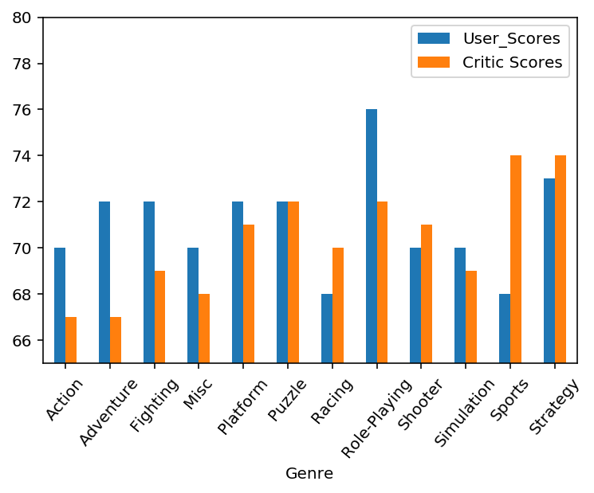

```python
df = pd.DataFrame({'User_Scores': user_score_list, 'Critic Scores': score_list}, index=Mean_User.columns)
ax = df.plot.bar(rot=50, ylim=(65,80))
```